# Seminárka_PSM_report

Radimský Jaroslav

2025-06-17

# 1. Data a charakteristiky

- Respondentů: **250**
- Průměrná skóre (1–10): IMAG **7.55**, EXPE **7.49**, QUAL **6.96**, VAL **7.08**, SAT **6.83**, LOY **7.24**

# 2. Spokojenost (SAT)

Lineární regrese identifikovala klíčové faktory:

- VAL: koeficient **0.5**
- IMAG: **0.19**, LOY: **0.12**

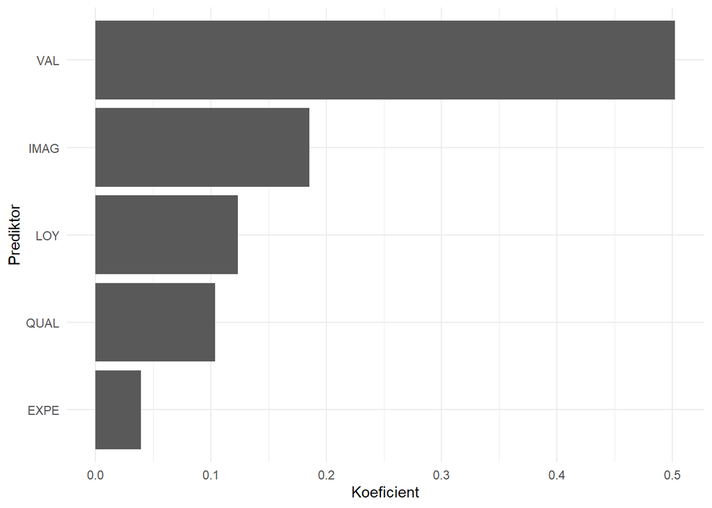

Regresní koeficienty pro SAT

# 3. Riziko odchodu klienta

Logistická regrese (odchod: switch>5) ukázala trend u IMAG:

- OR **1.34** (95% CI: 0.95–1.91)

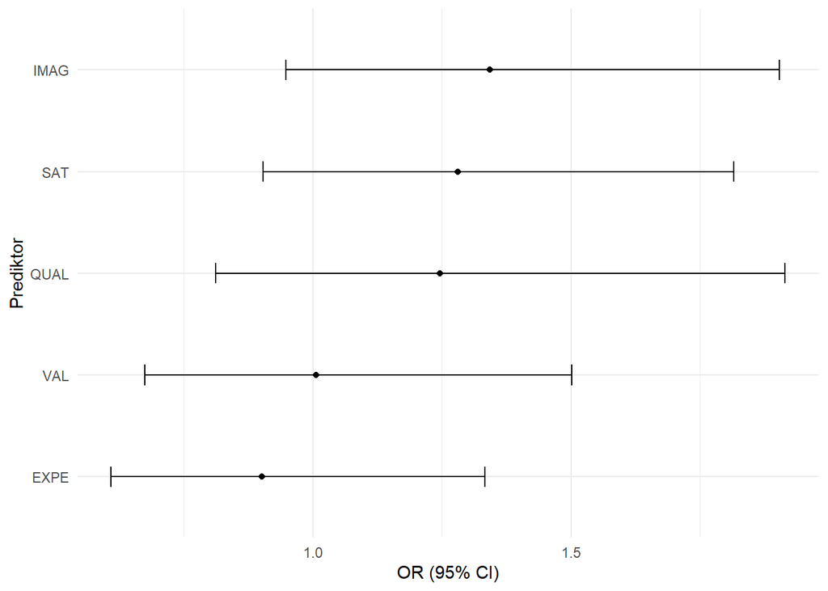

Poměry šancí pro odchod klienta

# 4. Segmentace LDA

- Rozdělení klientů do tři skupin (odcházející klient, spokojený zůstávající klient a nespokojený zůstávající klient) na základě 5 vybraných otázek
- Celková přesnost: **83.6%**

# 5. Shluková analýza

- 2 shluky (určeno pomocí “Elbow” metody):

```
##   cluster     IMAG     EXPE     QUAL      VAL      SAT      LOY
## 1       1 8.068852 8.078689 7.692896 7.866120 7.583333 7.967213
## 2       2 6.131343 5.898507 4.946269 4.940299 4.783582 5.242537
```

# 6. Korelace kompozitních skóre

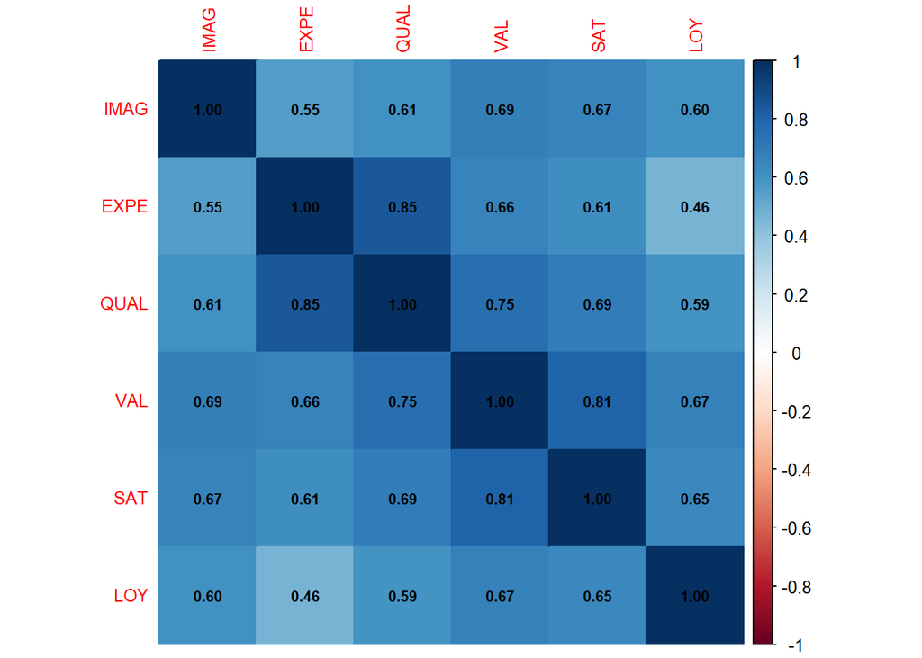

Korelace kompozitních skóre

# 7. Doporučení a kroky pro prezidenta banky

1. **Zacílení cenové politiky a budování reputace (VAL, IMAG)**
   - *Akce*: Prezident by měl iniciovat revizi cenových balíčků a komunikovat jejich výhody ve zvolených kanálech (e-mail, sociální sítě). Doporučuji založit tým, který bude sledovat zpětnou vazbu a upravovat nabídku.
2. **Monitorovat klienty s vysokým IMAG kvůli riziku odchodu**
   - *Akce*: Zřídit pravidelné reporty (např. měsíčně) pro top management, kde budou sledována změny skóre reputace (IMAG) u klíčových klientů. Prezident může svolávat kvartální schůzky, aby byl informován o vývojích.
3. **Využít segmenty (ambasadoři vs. ohrožení) pro cílené programy**
   - *Akce*: Spustit pilotní program odměn pro ambasadory (vysoké SAT, LOY), např. exkluzivní produkty či slevy. Současně vytvořit retenční balíčky pro ohrožené klienty s nízkým VAL a SAT.
4. **Pravidelná korelační kontrola pro optimalizaci dotazníku**
   - *Akce*: Prezident by měl nařídit interní revizi dotazníku každých 6 měsíců, aby se zaměřil pouze na nejvíce provázané a vlivné proměnné, čímž zkrátí délku a zlepší návratnost.

**Výsledkem těchto kroků** bude efektivnější alokace marketingových zdrojů, snížení rizika odchodu a posílení dlouhodobé loajality klientů.